# Background

Load the rwrfhydro package.

```r
library("rwrfhydro")
```

Set the working directory to the Fourmile Creek test case.

```r
setwd('/Users/adugger/WRF_Hydro/test_cases/Fourmile_Creek')
```

# Import modelled and observed datasets

Model 1: Only channel routing turned on (hourly model run).

```r
modStrh.chrt.fc <- ReadFrxstPts("OUTPUT_CHRT/frxst_pts_out.txt")
```

[output not shown]

Model 2: All WRF-Hydro routing options turned on (hourly model run).

```r
modStrh.allrt.fc <- ReadFrxstPts("OUTPUT_ALLRT/frxst_pts_out.txt")
```

[output not shown]

USGS gage observed data at 5-minute intervals.

```r
obsStr5min.fc <- ReadUsgsGage("OBS/5min_str_06727500_110401_140810.txt")
```

[output not shown]

# Plot hydrographs

Compare hydrographs for the full model run.

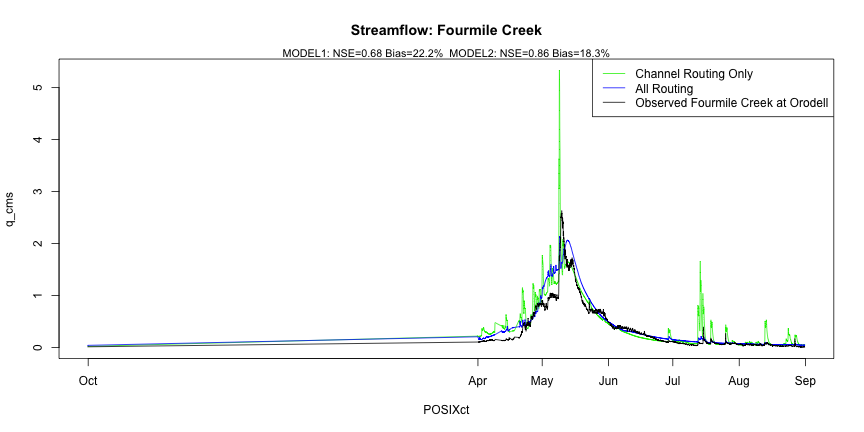

```r
PlotFluxCompare(obsStr5min.fc, "q_cms", modStrh.chrt.fc, "q_cms", strDf.mod2=modStrh.allrt.fc,
                strCol.mod2="q_cms", labelObs="Observed Fourmile Creek at Orodell",
                    labelMod1="Channel Routing Only", labelMod2="All Routing",
                    title="Streamflow: Fourmile Creek")
```

Now limit the plot to the June recession period only. The reported stats are updated to the new time period. (Note that the R warning is innocuous because the subset adjusts for timezone, so it's ok that the timezones dont match.)

```
## Warning in check_tzones(e1, e2): 'tzone' attributes are inconsistent
```

```
## Warning in check_tzones(e1, e2): 'tzone' attributes are inconsistent
```

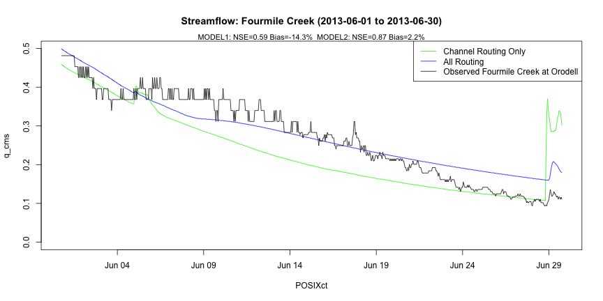

```r
PlotFluxCompare(obsStr5min.fc, "q_cms", modStrh.chrt.fc, "q_cms", strDf.mod2=modStrh.allrt.fc,
                strCol.mod2="q_cms", labelObs="Observed Fourmile Creek at Orodell",
                    labelMod1="Channel Routing Only", labelMod2="All Routing",
                    title="Streamflow: Fourmile Creek",
                stdate=as.POSIXct("2013-06-01 00:00:00", format="%Y-%m-%d %H:%M:%S", tz="UTC"),
                enddate=as.POSIXct("2013-06-30 00:00:00", format="%Y-%m-%d %H:%M:%S", tz="UTC"))
```

# Review flow duration curves

Calculate percent exceedances for flow duration curves.

```r
obsStr5min.fc <- CalcFdc(obsStr5min.fc)
modStrh.chrt.fc <- CalcFdc(modStrh.chrt.fc)
modStrh.allrt.fc <- CalcFdc(modStrh.allrt.fc)
```

Compare how the models are doing predicting flow values that will be exceeded 20% of the time. First, calculate the fitted spline functions.

```r
fdc.obsStr5min.fc <- CalcFdcSpline(obsStr5min.fc)
fdc.modStrh.chrt.fc <- CalcFdcSpline(modStrh.chrt.fc)
fdc.modStrh.allrt.fc <- CalcFdcSpline(modStrh.allrt.fc)
```

Then, evaluate at the 20% exceedance percentage (high flows).

```r
fdc.obsStr5min.fc(0.2)
fdc.modStrh.chrt.fc(0.2)
fdc.modStrh.allrt.fc(0.2)
```

[output not shown]

Now try the 80% exceedance percentage (low flows).

```r
fdc.obsStr5min.fc(0.8)
fdc.modStrh.chrt.fc(0.8)
fdc.modStrh.allrt.fc(0.8)
```

[output not shown]

Plot flow duration curves for a more complete picture.

```
## [1] "Combined min flow for y-axis (capped at 0.001): 0.00821188551168"
## [1] "Combined max flow for y-axis: 5.337"
```

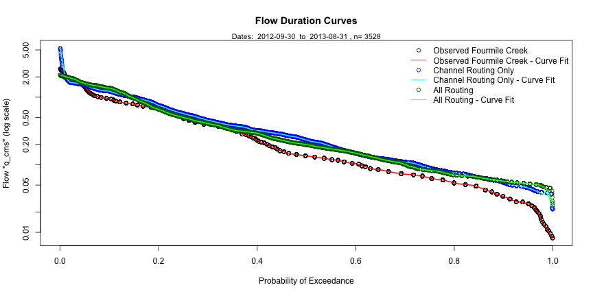

```r
PlotFdcCompare(obsStr5min.fc, "q_cms", modStrh.chrt.fc, "q_cms", strDf.mod2=modStrh.allrt.fc,
               strCol.mod2="q_cms", labelObs="Observed Fourmile Creek",
                   labelMod1="Channel Routing Only", labelMod2="All Routing")
```

# Review model performance statistics

```r
CalcModPerf(modStrh.allrt.fc, obsStr5min.fc)
```

[output not shown]

[output not shown]

[output not shown]

```r
CalcModPerf(modStrh.chrt.fc, obsStr5min.fc)
```

[output not shown]

[output not shown]

Help on CalcModPerf gives details on the individual statistics returned.

```r
help(CalcModPerf)
```

```r
CalcFdcPerf(modStrh.allrt.fc, obsStr5min.fc)
```

[output not shown]

[output not shown]

Again, help on CalcFdcPerf gives details on the individual statistics returned.

```r
help(CalcFdcPerf)
```